# TP 2 : Détection d’un changement ponctuel dans une suite binaire

##### Q6. Superposer en couleur orange la droite de régression linéaire de la variable $\theta$ par la variable y.

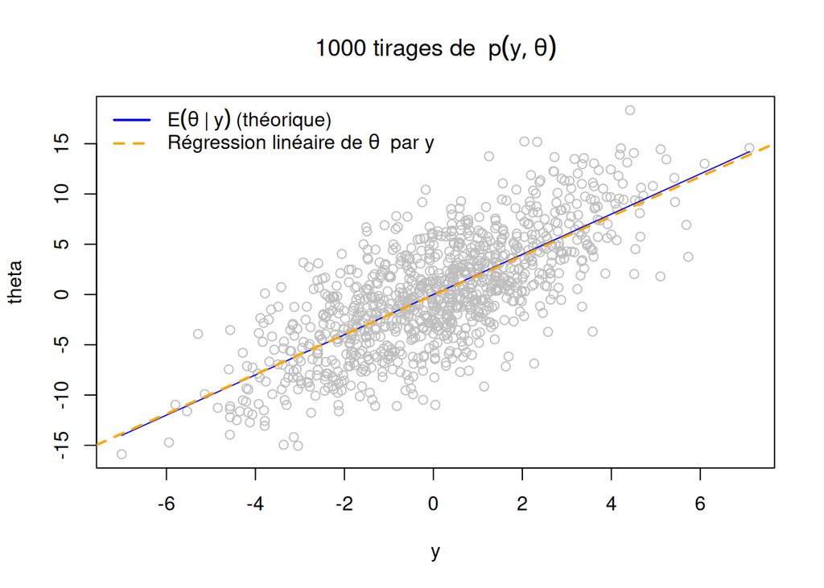

```r
plot(y, theta, col = "grey",
     main = expression("1000 tirages de " ~ p(y, theta)))

curve(2*x, col = "blue", add = TRUE)
droite_rl <- lm(theta ~ y)
abline(droite_rl, col = "orange", lty = 2, lwd = 2)
legend("topleft", legend = c(expression(E(theta ~ "|" ~ y) ~ "(théorique)"), expression("Régression linéaire de " * theta ~ " par " * y)), col = c("blue", "orange"), lwd = 2, lty = c(1,2), bty="n")
```

- La droite orange coïncide approximativement avec la bleue montre que la simulation est cohérente avec la théorie.

Le graphe confirme que les simulations respectent bien la loi conjointe donnée, avec une espérance conditionnelle parfaitement alignée sur la droite $\theta = 2y$

##### Q7. Effectuer 100000 tirages de la loi $p(y, \theta)$. Programmer en langage $R$ un algorithme rejetant les valeurs de la variable $\theta$ telles que la variable y se trouve en dehors de l’intervalle 1.99, 2.01.

```r
N <- 100000
theta <- rnorm(N, mean = 0, sd = sqrt(32)) # simuler theta ~ N(0, 32)
y <- rnorm(N, mean = theta/4, sd = sqrt(2)) # simuler y|theta ~ N(theta/4, 2)
sim_data <- data.frame(theta = theta, y = y)

theta_q7 <- theta[y<= 2.01 & y>=1.99]
```

##### Q8. Tracer l’histogramme des valeurs retenues par l’algorithme. Interpréter l’histogramme ainsi obtenu.

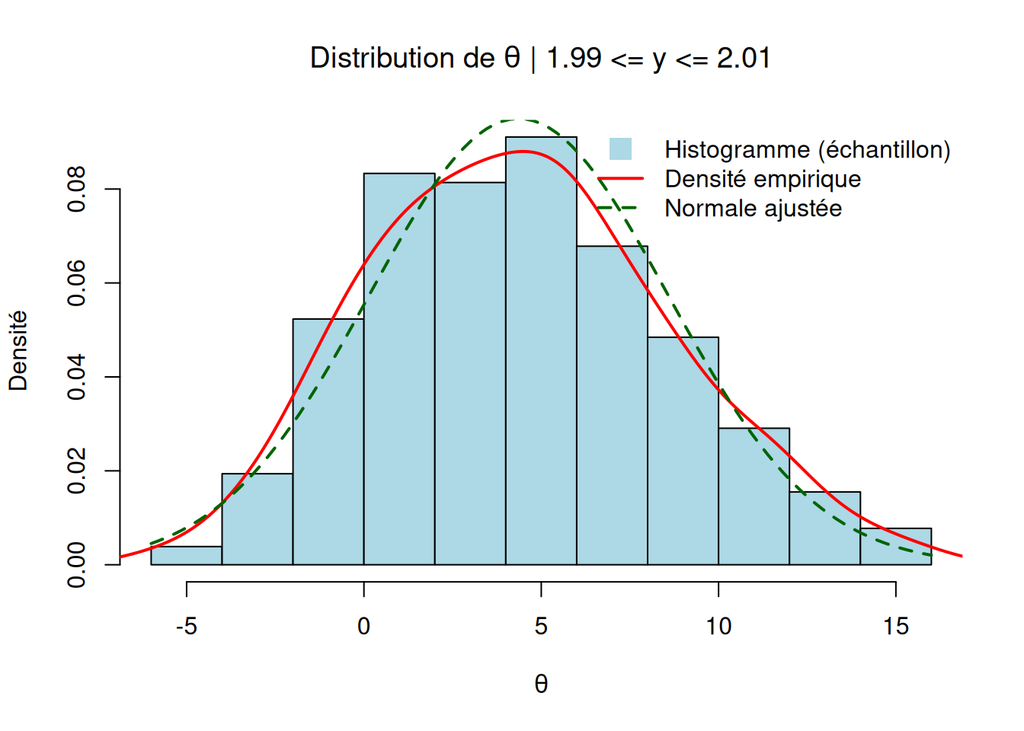

```r
hist(theta_q7, prob = TRUE, col = "lightblue", main = expression("Distribution de " * theta * " | 1.99 <= y <= 2.01"), xlab = expression(theta), ylab = "Densité")

lines(density(theta_q7), col = "red", lwd=2 )
curve(dnorm(x, mean = mean(theta_q7), sd = sd(theta_q7)),
      col = "darkgreen",
      lwd = 2,
      lty = 2,
      add = TRUE)
legend("topright",
       legend = c("Histogramme (échantillon)",
                  "Densité empirique",
                  "Normale ajustée"),
       col = c("lightblue", "red", "darkgreen"),
       lty = c(NA, 1, 2),
       lwd = c(NA, 2, 2),
       pch = c(15, NA, NA),
       pt.cex = 2,
       bty = "n")
```

On remarque que le nombre d’échantillons accepté << 10 000 vu la restriction sur y

On sait que
$$\theta \mid y \sim
\mathcal{N}\Big(m = 2y, \, \sigma^2 = 16 \Big)$$
, l’histogramme montre qu’on a une loi normale centrée autour 4 = 2 * y (1.99 <= y <= 2.01 donc y $\approx$ 2)

```r
mean(theta_q7)
```

```
## [1] 4.363163
```

```r
sd(theta_q7)
```

```
## [1] 4.199036
```

Ce qui confirme ce qu’on a obtenu théoriquement !

##### Q9. Justifier le fait que la loi de densité $p(y, \theta)$ est caractérisée par la donnée des lois conditionnelles $p(y|\theta)$ et $p(\theta|y)$.

On a d’après la formule de Bayes :

$$p(y,\theta) = p(y \mid \theta)\, p(\theta) = p(\theta \mid y)\, p(y)$$

En particulier, on peut exprimer la densité marginale $p(\theta)$ à partir de la conditionnelle $p(\theta\mid y)$ et de la marginale $p(y)$ :
$$p(\theta)=\int p(\theta\mid y)\,p(y)\,dy.$$

Ainsi, la loi conjointe $p(y,\theta)$ est entièrement caractérisée :

- soit par la loi conditionnelle $p(y \mid \theta)$ et la loi marginale $p(\theta)$
- soit par la loi conditionnelle $p(\theta \mid y)$ et la loi marginale $p(y)$

En d’autres termes, connaître les lois conditionnelles permet de reconstruire complètement la loi conjointe.

##### Q10. Ecrire un programme en langage $R$ permettant de simuler l’algorithme d’échantillonnage de Gibbs. Effectuer 1000 tirages du couple $(y, \theta)$ en prenant 1000 valeurs successives après avoir éliminé les premières valeurs afin de perdre la condition initiale.

```r
set.seed(123)
n_iter <- 2000   # nombre total d'itérations
n_elimine <- 1000  # pour perdre la condition initiale
theta <- numeric(n_iter)
y <- numeric(n_iter)
theta[1] <- 0

for (t in 2:n_iter) {
  y[t] <- rnorm(1, mean = theta[t-1]/4, sd = sqrt(2))
  theta[t] <- rnorm(1, mean = y[t]*2, sd = sqrt(16))
}

theta_post <- theta[(n_elimine+1):n_iter]
y_post <- y[(n_elimine+1):n_iter]

cat("2000 itérations avec élimination de 1000 :\n")
```

```
## 2000 itérations avec élimination de 1000 :
```

```r
cat("Moyenne de y :", mean(y_post), "\n")
```

```
## Moyenne de y : -0.07300439
```

```r
cat("Moyenne de theta :", mean(theta_post), "\n\n")
```

```
## Moyenne de theta : -0.2059937
```

```r
n_iter2 <- 1010   # nombre total d'itérations
n_elimine2 <- 10  # pour perdre la condition initiale

theta2 <- numeric(n_iter2)
y2 <- numeric(n_iter2)
theta2[1] <- 0

for (t in 2:n_iter2) {
  y2[t] <- rnorm(1, mean = theta2[t-1]/4, sd = sqrt(2))
  theta2[t] <- rnorm(1, mean = y2[t]*2, sd = sqrt(16))
}

theta_post2 <- theta2[(n_elimine2+1):n_iter2]
y_post2 <- y2[(n_elimine2+1):n_iter2]

cat("1010 itérations avec élimination de 10 :\n")
```

```
## 1010 itérations avec élimination de 10 :
```

```r
cat("Moyenne de y :", mean(y_post2), "\n")
```

```
## Moyenne de y : 0.02303286
```

```r
cat("Moyenne de theta :", mean(theta_post2), "\n")
```

```
## Moyenne de theta : -0.05454417
```

On observe que les moyennes de y et theta sont très proches de la valeur théorique dans les deux simulations, malgré le nombre différent d’itérations éliminées. Cela peut être justifié par la convergence rapidement des éléments vers 0, et qu’$n\_elimine$ très grand n’est pas nécessaire dans ce cas précis pour perdre la condition initiale

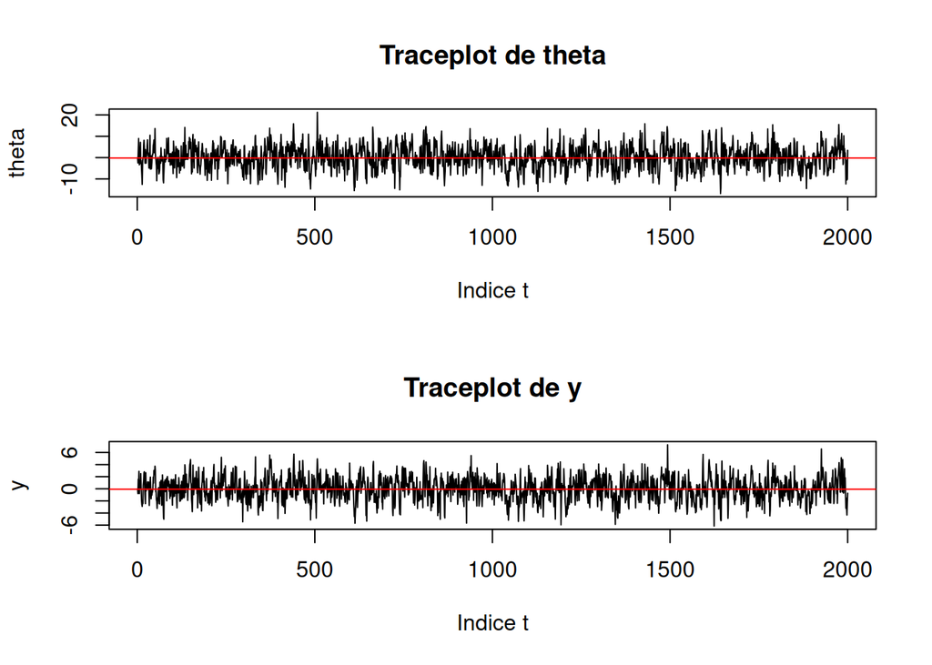

```r
par(mfrow = c(2,1))
plot(theta, type = "l", main = "Traceplot de theta", xlab = "Indice t", ylab = "theta")
abline(h = mean(theta_post), col = "red")

plot(y, type = "l", main = "Traceplot de y",xlab = "Indice t", ylab = "y")
abline(h = mean(y_post), col = "red")
```

Cela indique que les variables ont convergé rapidement et que le $n\_elimine$ n’a pas besoin d’être très grand

Conclusion : Le nombre d’itérations éliminées n’a pas beaucoup d’importance ici.